# Final Project

Adam Guerra

2022-11-20

#### Step 1: Set global options and load packages.

#### Step 2: Import country data; clean data.

**Q1: What data are you using?**  
I am using water use data from every country. This includes it broken down by sector, and as a total. Also I have population data and HDI (human development index) data. All of this data for 2000 - 2019.

**Q2: Where are the data from?**  
All the data I got is from FAO AQUASTAT.

**Q3: Using these data, what figures will you make?**  
I plan on making one bar graph that will show the water use per capita for all countries arranged by increasing HDI. Also potentially a plot that looks at the lowest HDIs, showing the water use over the course of the 2000s. The second plot may change but I want to do a second plot.

**Q4: What is the main point of each of your figures?**  
The main point of the first figure is to look at how per capita water use changes depending on how developed a country is based on the human development index. The purpose of the second graph is to take a closer look at how both time and further development effect water use trends in developing nations (2000 - 2019).

**Q5: Why did you choose the data that you chose? Why did you choose the topic that you choose?**  
I chose this topic because I thought it would be interesting to look at water use beyond the United States, and look at how it changes based on how developed a country is. The data I chose will help me do that and it was all found together which will minimize the need to combine data sets.

**Q6: In what ways are you hoping this project challenges you?**  
I am hoping this project challenges me to manipulate data without guidelines. This whole year we have always had some direction and I think that this will be a good challenge to manipulate the data and create visualizations by following my own guidelines. So far the project has already challenged me to look at water data in a different way, I spent a good amount of time trying to come up with my first visual and even now I still am not set on my second graph because I keep trying to come up with a better visual. Another way I hope it will challenge me is in hopefully trying new things and becoming more efficient at solving my own coding problems.

```r
country_data <- read_xlsx(here("data/country_data.xlsx")) |>                    #import data, assign to data frame
                clean_names()                                                   #clean names
```

#### Step 3: Set up data for plots 1 and 2.

```r
plot1_data <-   country_data |>                                                 #create plot 1 data frame
                filter(year %in% c(2019), variable %in% c("Total population",   #filter by year for 2019
                       "Total freshwater withdrawal",                           #filter desired rows
                       "Human Development Index (HDI) [highest = 1]",
                       "Agricultural water withdrawal",
                       "Industrial water withdrawal",
                       "Municipal water withdrawal",
                       "Irrigation water withdrawal",
                       "Water withdrawal for aquaculture",
                       "Water withdrawal for cooling of thermoelectric plants",
                       "Water withdrawal for livestock (watering and cleaning)")) |>
                pivot_wider(names_from = "variable", values_from = "value") |>  #pivot data to wide
                clean_names() |>                                                #clean names
                select(hdi = human_development_index_hdi_highest_1,             #select needed columns and rename
                       country,
                       year,
                       total_fresh = total_freshwater_withdrawal,
                       total_pop = total_population,
                       agriculture = agricultural_water_withdrawal,
                       industrial = industrial_water_withdrawal,
                       municipal = municipal_water_withdrawal,
                       irrigation = irrigation_water_withdrawal,
                       aquaculture = water_withdrawal_for_aquaculture,
                       thermoelecric = water_withdrawal_for_cooling_of_thermoelectric_plants,
                       livestock = water_withdrawal_for_livestock_watering_and_cleaning) |>
                group_by(country, year) |>                                      #group by country and year
                summarise(across(c(hdi, total_pop, total_fresh, agriculture,    #summarize across to combine rows
                                   industrial, municipal, irrigation, aquaculture,
                                   thermoelecric, livestock),
                                 sum, na.rm = TRUE)) |>                         #make sure na values are accounted for.
                ungroup() |>                                                    #ungroup data
                mutate(total_fresh = total_fresh * 10^9,                        #change total_fresh to have proper units
                       total_pop = total_pop * 1000,                            #change total_pop to have proper units
                       total_fresh_per_capita = total_fresh / total_pop) |>     #create per capita data
                arrange(hdi) |>                                                 #arrange plot by hdi
                filter(hdi != 0, total_fresh != 0) |>                           #filter out unavailable data
                pivot_longer(cols = 6:12, names_to = "Sector",                  #pivot data back to long
                             values_to = "Withdrawal") |>
                mutate(Withdrawal = Withdrawal * 10^9)                          #change withdrawal to have proper units
```

#### Step 4: Plot 1

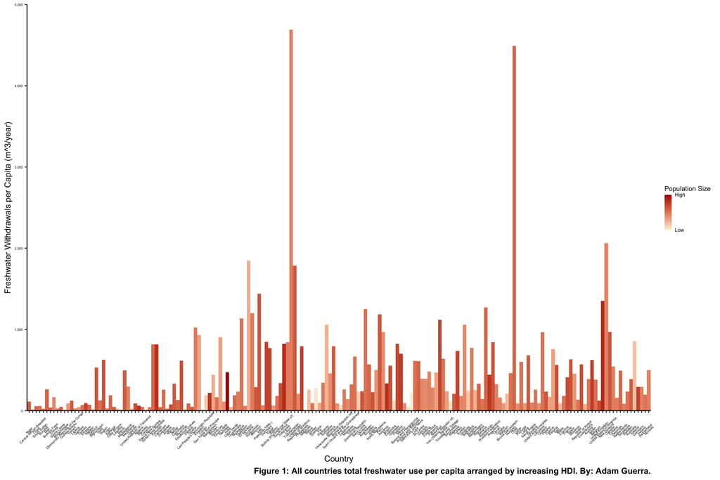

```r
ggplot() +                                                                      #create ggplot
  geom_col(data = plot1_data,                                                   #set plot1_data as data
           aes(x = reorder(country, hdi),                                       #set x axis and order
               y = total_fresh_per_capita,                                      #set y axis
               fill = log(total_pop)),                                          #set fill as log of pop
           position = position_dodge(3.5), width = 1,                           #position dodge and width of bars
           show.legend = TRUE) +                                                #show legend
  labs(x = "Country", y = "Freshwater Withdrawals per Capita (m^3/year)",       #set x,y, caption labels
       caption = "Figure 1: All countries total freshwater use per capita arranged by increasing HDI. By: Adam Guerra.",
       fill = "") +                                                             #set blank fill
  ggplot2::theme_classic() +                                                    #set classic theme
  theme(axis.text = element_text(size = 4, color = "black"),                    #axis text size and color
        axis.title = element_text(size = 10, color = "black"),                  #axis title size and color
        axis.text.x = element_text(angle = 45, vjust = 0.6),                    #x axis text angle change
        plot.caption = element_text(size = 10, color = "black", face = "bold"), #plot caption size, color, bold
        legend.position = "right",                                              #legend position right
        legend.key.size = unit(0.3, "cm"),                                      #change legend key size
        legend.text = element_text(size = 6),                                   #set legend text size
        legend.title = element_text(size = 8)) +                                #set legend title size
  scale_y_continuous(labels = scales::comma,                                    #comma separate y axis values
                     limits = c(0, 5000),                                       #set range limits
                     expand = c(0,0)) +                                         #have bars start at y = 0
  scale_fill_gradient(low = "#fef0d9", high = "#b30000",                        #legend low and high colors
                      name = "Population Size",                                 #legend name
                      breaks = c(log(52823), log(1366417754)),                  #set breaks on legend scale
                      labels = c("Low", "High"))                                #change legend scale names
```

**Q2: What is most (or least) surprising?**  
The least surprising part of the data was that the lower developed nations on the far left had low per capita use rates because their population is not the high, nor do they have the same access to water as some slightly more developed nations. Likely due to infrastructure or geographic location.

**Q3: What three new functions did you implement to support visualization of the data? Explain what each of them does.**  
In this first plot I only used new parameters within the scale_fill_gradient function. My other plots contain new functions.

#### Step 5: Plot 2

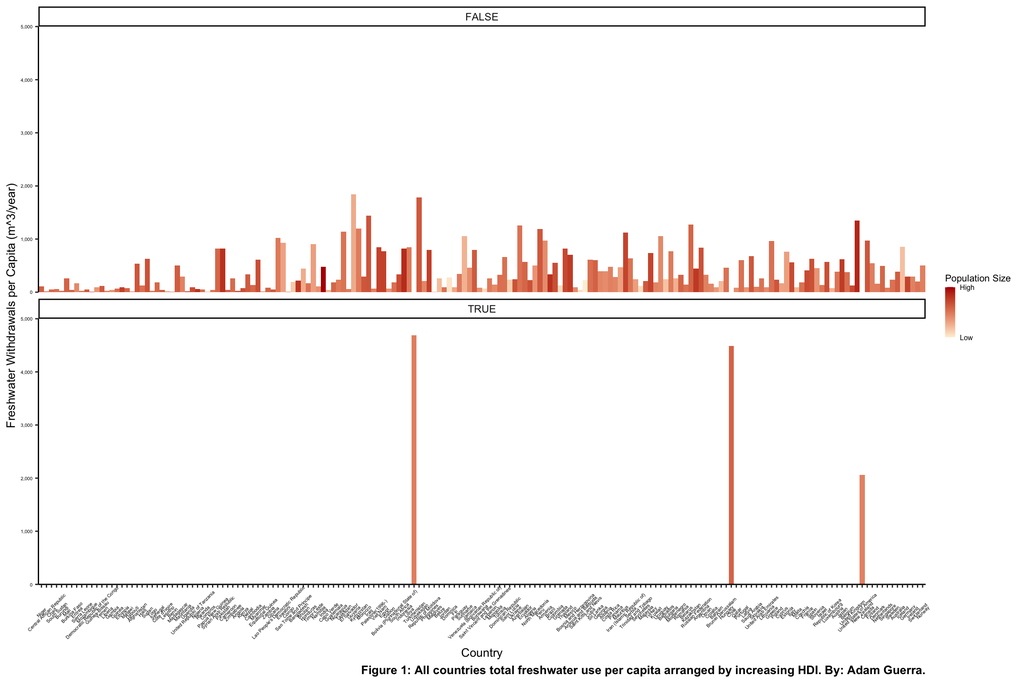

```r
ggplot() +                                                                      #create ggplot
  geom_col(data = plot1_data,                                                   #set plot1_data as data
           aes(x = reorder(country, hdi),                                       #set x axis and order
               y = total_fresh_per_capita,                                      #set y axis
               fill = log(total_pop)),                                          #set fill as log of pop
           position = position_dodge(3.5), width = 1,                           #position dodge and width of bars
           show.legend = TRUE) +                                                #show legend
  labs(x = "Country", y = "Freshwater Withdrawals per Capita (m^3/year)",       #set x,y, caption labels
       caption = "Figure 1: All countries total freshwater use per capita arranged by increasing HDI. By: Adam Guerra.",
       fill = "") +                                                             #set blank fill
  ggplot2::theme_classic() +                                                    #set classic theme
  theme(axis.text = element_text(size = 4, color = "black"),                    #axis text size and color
        axis.title = element_text(size = 10, color = "black"),                  #axis title size and color
        axis.text.x = element_text(angle = 45, vjust = 0.6),                    #x axis text angle change
        plot.caption = element_text(size = 10, color = "black", face = "bold"), #plot caption size, color, bold
        legend.position = "right",                                              #legend position right
        legend.key.size = unit(0.3, "cm"),                                      #change legend key size
        legend.text = element_text(size = 6),                                   #set legend text size
        legend.title = element_text(size = 8)) +                                #set legend title size
  scale_y_continuous(labels = scales::comma,                                    #comma separate y axis values
                     limits = c(0, 5000),                                       #set range limits
                     expand = c(0,0)) +                                         #have bars start at y = 0
  scale_fill_gradient(low = "#fef0d9", high = "#b30000",                        #legend low and high colors
                      name = "Population Size",                                 #legend name
                      breaks = c(log(52823), log(1366417754)),                  #set breaks on legend scale
                      labels = c("Low", "High")) +                              #change legend scale names
  facet_wrap(vars(total_fresh_per_capita > 2000),                               #remove outliers based on per capita
             nrow = 2, ncol = 1)                                                #change plot arrangement
```

**Q2: What is most (or least) surprising?**  
The most surprising part of this plot was that the two out of three of the outliers are on the more developed side of the plot. Later on I may revisit to take a deeper look at those outliers and see why they might have higher per capita usage.

**Q3: What three new functions did you implement to support visualization of the data? Explain what each of them does.**  
In this plot I Incorporated facet_wrap. This allowed me to make two subplots from the main plot (plot 1) where I removed the outliers from the data so I can compare them to each other and also see if my main hypothesis lines up better with them gone.

#### Step 6: Set up data for plots 3 and 4.

```r
niger_data <- country_data |>                                                   #create niger data frame
              filter(year %in% c(2019), country %in% c("Niger"),                #filter by year and niger
                     variable %in% c("Municipal water withdrawal",              #filter by desired rows
                                     "Industrial water withdrawal",
                                     "Irrigation water withdrawal",
                                     "Agricultural water withdrawal",
                                     "Water withdrawal for livestock (watering and cleaning)")) |>
               select(country, year, sector = variable, withdrawal = value) |>  #select and rename columns
               mutate(withdrawal = withdrawal * 10^9, total = sum(withdrawal),  #mutate withdrawal to have units
                      dec = withdrawal / total, percent = scales::percent(dec)) #create dec, percent, total columns

norway_data <- country_data |>                                                  #create norway data frame
              filter(year %in% c(2019), country %in% c("Norway"),               #filter by year and norway
                     variable %in% c("Municipal water withdrawal",              #filter desired rows
                                     "Industrial water withdrawal",
                                     "Irrigation water withdrawal",
                                     "Agricultural water withdrawal")) |>
               select(country, year, sector = variable, withdrawal = value) |>  #select and rename columns
               mutate(withdrawal = withdrawal * 10^9, total = sum(withdrawal),  #mutate withdrawal to have units
                      dec = withdrawal / total, percent = scales::percent(dec)) #create dec, percent, total columns
```

#### Step 7: Plots 3 and 4.

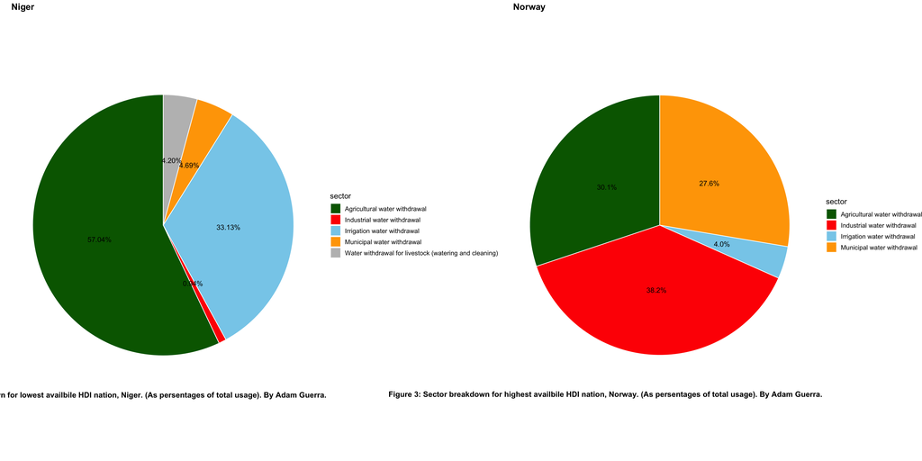

```r
p3 <- ggplot(data = niger_data, aes(x = "", y = dec, fill = sector)) +          #create niger plot
  geom_col(color = "white") +                                                   #set color to white
   geom_text(aes(label = percent),                                              #create geom for labels on chart
            position = position_stack(vjust = 0.5)) +                           #stack labels over pie chart
  coord_polar("y", start=0) +                                                   #set coord system to polar
  theme_void() +                                                                #theme to eliminate background
  labs(caption = "Figure 3: Sector breakdown for lowest availbile HDI nation, Niger. (As persentages of total usage). By Adam Guerra.") +
  theme(plot.caption = element_text(size = 12, color = "black", face = "bold"), #plot caption size, color, bold
        legend.text = element_text(size = 10),                                  #legend text size
        legend.title = element_text(size = 12)) +                               #legend ittle size
  scale_fill_manual(values = c("dark green", "red", "sky blue", "orange", "grey")) #change legend colors

 p4 <- ggplot(data = norway_data, aes(x = "", y = dec, fill = sector)) +        #create norway plot
  geom_col(color = "white") +                                                   #set color to white
   geom_text(aes(label = percent),                                              #create geom for labels chart
            position = position_stack(vjust = 0.5)) +                           #stack labels over pie chart
  coord_polar("y", start = 0) +                                                 #set coord system to polar
  theme_void() +                                                                #set void theme
  labs(caption = "Figure 3: Sector breakdown for highest availbile HDI nation, Norway. (As persentages of total usage). By Adam Guerra.") +
  theme(plot.caption = element_text(size = 12, color = "black", face = "bold"), #plot caption size, color, bold
        legend.text = element_text(size = 10),                                  #legend text size
        legend.title = element_text(size = 12)) +                               #legend title size
   scale_fill_manual(values = c("dark green", "red", "sky blue", "orange"))     #change legend colors

 plot_grid(p3, p4, labels = c('Niger', 'Norway'),                               #move plots side by side
           label_size = 14, rel_widths = c(1.17,1))                             #change label size and width of plots
```

**Q1: What is the take home message of this figure?**  
This plot is technically two plots combined into one. The purpose is to compare the highest HDI to the lowest HDI nations to see how their breakdown of fresh water usage differs. It highlights exactly what most would expect, that the more developed nation has higher amounts dedicated to municipal and industrial. The lower HDI nation had more dedicated to agriculture and irrigation.

**Q2: What is most (or least) surprising?**  
The least surprising part of the plot was that the more developed nation transitioned away from agriculture and irrigation. This may be partially due to HDI but could also have to do with population demand and geographic location.

**Q3: What three new functions did you implement to support visualization of the data? Explain what each of them does.**  
In these two plots I implemented coord_polar to make a pie chart within ggplot. This allowed me to visualize the their water usage as fractions of a whole for the sake of direct comparison. I also used a new package (cowplot) and used the function plot_grid to place these two plots side by side in my knitted file. This was no possible using basic R commands with ggplot. This makes it easier for viewers to compare side by side rather than verically.